# Modulo 9 Tarea 1

```python
#Prepare the Describe Statics to do some analysis between both samples.
Xtrain_describe= Xtrain.describe().round(2).T
Xtrain_describe = Xtrain_describe[['mean','std','min','25%','50%','75%','max']]
Xtrain_describe['mean'].astype(int)
Xtrain_describe['std'].astype(int)
```

```
Year                    0
Month                   3
DayofMonth              8
DayOfWeek               2
DepTime               450
CRSDepTime            424
ArrTime               548
CRSArrTime            464
FlightNum            1945
ActualElapsedTime      72
CRSElapsedTime         71
AirTime                68
ArrDelay               56
DepDelay               53
Distance              574
TaxiIn                  5
TaxiOut                14
Cancelled               0
Diverted                0
CarrierDelay           43
WeatherDelay           21
NASDelay               33
SecurityDelay           2
LateAircraftDelay      42
Name: std, dtype: int64
```

```python
#Lets see some values from the column Arrival Delay:
Xtrain_describe.iloc[7]
```

```
mean    1634.41
std      464.50
min        0.00
25%     1325.00
50%     1706.00
75%     2015.00
max     2400.00
Name: CRSArrTime, dtype: float64
```

```python
Xtest_describe= Xtest.describe().round(2).T
Xtest_describe = Xtest_describe[['mean','std','min','25%','50%','75%','max']]
Xtest_describe['mean'].astype(int)
Xtest_describe['std'].astype(int)
```

```
Year                    0
Month                   3
DayofMonth              8
DayOfWeek               2
DepTime               451
CRSDepTime            425
ArrTime               548
CRSArrTime            465
FlightNum            1945
ActualElapsedTime      72
CRSElapsedTime         71
AirTime                68
ArrDelay               56
DepDelay               53
Distance              574
TaxiIn                  5
TaxiOut                14
Cancelled               0
Diverted                0
CarrierDelay           43
WeatherDelay           22
NASDelay               33
SecurityDelay           2
LateAircraftDelay      42
Name: std, dtype: int64
```

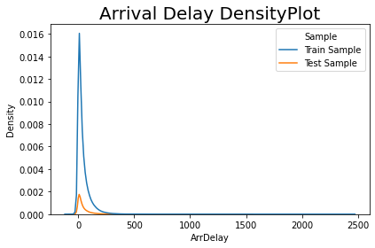

```python
#Plot the density of Arrival Delay between our Train and Test Sample:
%matplotlib inline
sns.kdeplot(data=df_concat, x="ArrDelay", hue="Sample")
plt.title("Arrival Delay DensityPlot",fontsize=20)
plt.tight_layout()
plt.show()
```

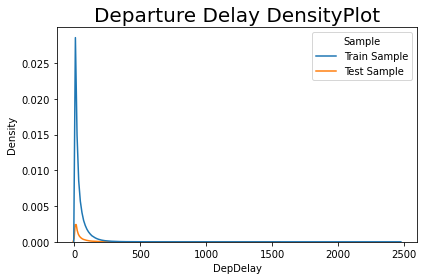

```python
#Plot the density of Departure Delay between our Train and Test Sample:
%matplotlib inline
sns.kdeplot(data=df_concat, x="DepDelay", hue="Sample")
plt.title("Departure Delay DensityPlot",fontsize=20)
plt.tight_layout()
plt.show()
```

We got the same answer that we got above. Same distribution but different sizes.

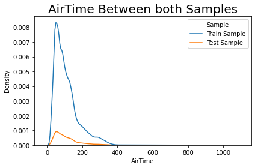

```python
#Plotting the Variable AirTime to analyse also.
%matplotlib inline
sns.kdeplot(data=df_concat, x="AirTime", hue="Sample")
plt.title("AirTime Between both Samples",fontsize=20)
plt.tight_layout()
plt.show()
```

Again, same AirTime distribution but different sizes.

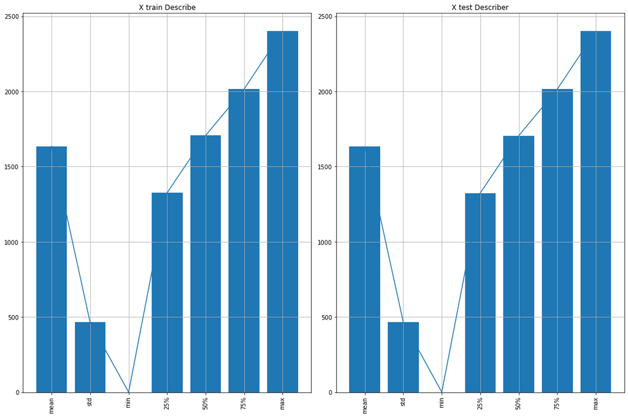

```python
###Plotting the "Describe Statics" to see how simmilar they are between Train and Test Sample:
%matplotlib inline
#plot 1:
fig,axes = plt.subplots(1,2, figsize=(15,10))

x_values = Xtrain_describe.columns
y_values = Xtrain_describe.iloc[7]
axes[0].bar(x_values, y_values)
axes[0].set(title='X train Describe')
axes[0].set_xticklabels(rotation=90, labels=x_values)
axes[0].grid()
axes[0].plot(x_values, y_values)


#plot 2:
x_values2 = Xtest_describe.columns
y_values2 = Xtest_describe.iloc[7]
axes[1].bar(x_values2, y_values2)
axes[1].set(title='X test Describer')
axes[1].set_xticklabels(rotation=90, labels=x_values)
axes[1].plot(x_values2, y_values2)

axes[1].grid()






plt.tight_layout()
plt.show()
```

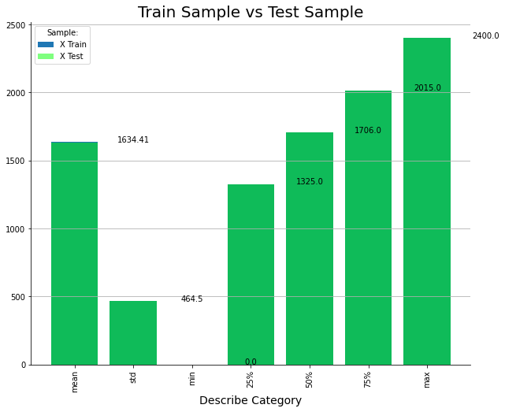

```python
#Plotting the Describe Statics but now in a single stacked bar plot:
%matplotlib inline

#Set the size
fig, ax = plt.subplots(figsize=(10,8))

def add_value_label(x_list,y_list):
    for i in range(1, len(x_list)+1):
        plt.text(i,y_list[i-1],y_list[i-1], ha="center")

ax.bar(x_values,y_values, label="X Train")
ax.bar(x_values2,y_values2, label= "X Test",color='lime',  alpha=0.5)
ax.set_title("Train Sample vs Test Sample",fontsize=20)
#ax.set_ylabel("Proportion", fontsize=14)
ax.set_xlabel("Describe Category", fontsize=14)

ax.spines['top'].set_visible(False)
ax.spines['right'].set_visible(False)

add_value_label(x_values,y_values)


ax.yaxis.grid(True)
ax.xaxis.grid(False)
plt.xticks(rotation=90)
plt.legend(loc="best", title="Sample:")



plt.show()
```

### We can see that we have pretty similar Statics from the Train and the Test Sample, so much that they don't even differ in the graph.

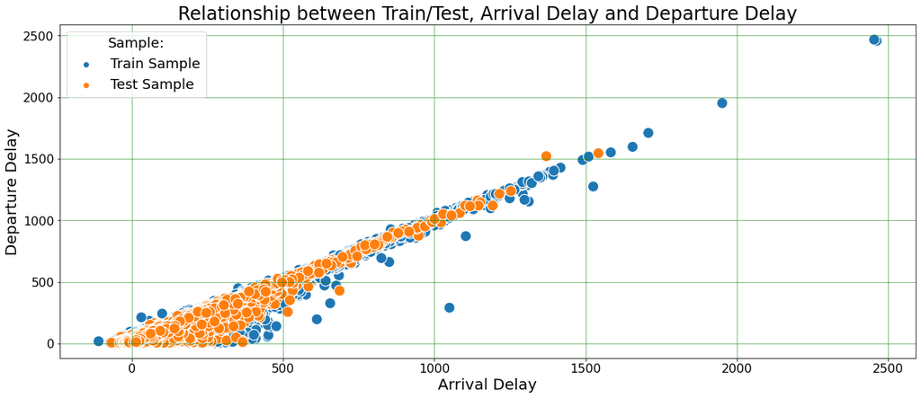

```python
#Now we are going to print a Scatter plot to see the relationship between Arrival Delay, Departure Delay, and the Samples:
# Lest set the size of the figure

plt.figure(figsize =(20, 8))

#Choosing the type of chart
sns.scatterplot(data=df_concat, x='ArrDelay', y='DepDelay',  hue="Sample", s=200)

#Set title, labels, etc.

plt.title("Relationship between Train/Test, Arrival Delay and Departure Delay",fontsize=24)
plt.xlabel("Arrival Delay", fontsize=20)
plt.ylabel("Departure Delay", fontsize=20)
plt.xticks(fontsize=16)
plt.yticks(fontsize=16)
plt.grid(color='g', linestyle='-', linewidth=0.5)
plt.legend(title="Sample:", title_fontsize=18, fontsize=18, loc="best")

#plt.savefig('Scatterplot.png')
plt.show()
```

```python
#Lets check another values and see if we got similar values for the mean Arrival Delay:
mean_xtrain_arr = Xtrain['ArrDelay'].mean()
mean_xtest_arr = Xtest['ArrDelay'].mean()
print(mean_xtrain_arr)
print(mean_xtest_arr)
```

```
42.20584374801934
42.146255205065316
```

As we can see we have very similar values for mean.

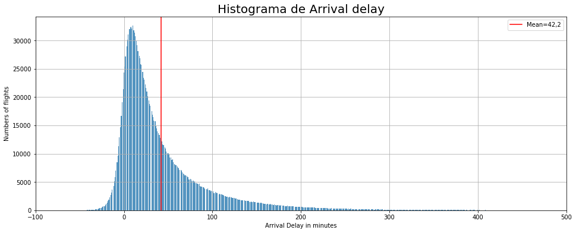

```python
#Lets plot a Historigram to see the distribution of data that the column Arrival Delay ("ArrDealy") have:
plt.figure(figsize=(16, 6))
sns.histplot(data=Xtrain, x='ArrDelay')
#Add the mean line.
plt.axvline(x=mean_xtrain_arr, color='red', label='Mean=42,2')
plt.xlim(-100,500,1)
plt.xlabel('Arrival Delay in minutes')
plt.ylabel('Numbers of flights')
plt.title('Histograma de Arrival delay', fontsize=20)
plt.grid()

plt.legend()
```

The average of arrivals delays is 42 minutes. Notice that we have negative values this is because the plane can arrive On time wich is 0min, or arrive early.

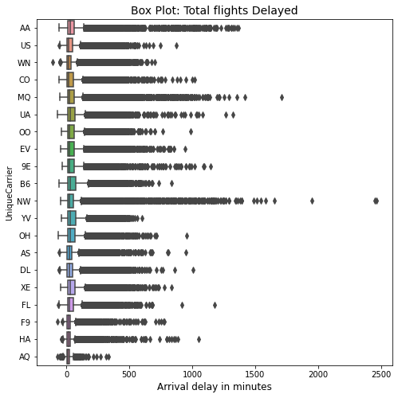

```python
#Lets plot a boxplot to see the values and outliers of Arrival Delay from every Airline:
%matplotlib inline
fig = plt.figure(figsize=(8,8))

sns.boxplot(x=Xtrain.ArrDelay, y=Xtrain.UniqueCarrier)
plt.title('Box Plot: Total flights Delayed', fontsize=14)
plt.xlabel("Arrival delay in minutes",fontsize=12)




plt.show()
```

### Conlusion: We don´t imput any data to our null values, but if its convinient we can imput with the mean or the median. Personally i choose to keep the values becouse i want to analyse the entire dataset knowing my outliers.

### I did the comparison between Train and Test Samples and plot some charts to show that they have similar statics in both samples.

### Exercice 2: Apply some transformation process (standardize numerical data, create dummy columns, polynomials ...)

```python
df.info()
```

```
<class 'pandas.core.frame.DataFrame'>
Int64Index: 1936758 entries, 0 to 7009727
Data columns (total 29 columns):
 #   Column             Dtype
---  ------             -----
 0   Year               int64
 1   Month              int64
 2   DayofMonth         int64
 3   DayOfWeek          int64
 4   DepTime            float64
 5   CRSDepTime         int64
 6   ArrTime            float64
 7   CRSArrTime         int64
 8   UniqueCarrier      object
 9   FlightNum          int64
```

[output cut: 21 more lines]

```python
df.select_dtypes(include=['float64','int64'])
```

|  | Year | Month | DayofMonth | DayOfWeek | DepTime | CRSDepTime | ArrTime | CRSArrTime | FlightNum | ActualElapsedTime | ... | Distance | TaxiIn | TaxiOut | Cancelled | Diverted | CarrierDelay | WeatherDelay | NASDelay | SecurityDelay | LateAircraftDelay |
| --- | --- | --- | --- | --- | --- | --- | --- | --- | --- | --- | --- | --- | --- | --- | --- | --- | --- | --- | --- | --- | --- |
| 0 | 2008 | 1 | 3 | 4 | 2003.0 | 1955 | 2211.0 | 2225 | 335 | 128.0 | ... | 810 | 4.0 | 8.0 | 0 | 0 | NaN | NaN | NaN | NaN | NaN |
| 1 | 2008 | 1 | 3 | 4 | 754.0 | 735 | 1002.0 | 1000 | 3231 | 128.0 | ... | 810 | 5.0 | 10.0 | 0 | 0 | NaN | NaN | NaN | NaN | NaN |
| 2 | 2008 | 1 | 3 | 4 | 628.0 | 620 | 804.0 | 750 | 448 | 96.0 | ... | 515 | 3.0 | 17.0 | 0 | 0 | NaN | NaN | NaN | NaN | NaN |
| 4 | 2008 | 1 | 3 | 4 | 1829.0 | 1755 | 1959.0 | 1925 | 3920 | 90.0 | ... | 515 | 3.0 | 10.0 | 0 | 0 | 2.0 | 0.0 | 0.0 | 0.0 | 32.0 |
| 5 | 2008 | 1 | 3 | 4 | 1940.0 | 1915 | 2121.0 | 2110 | 378 | 101.0 | ... | 688 | 4.0 | 10.0 | 0 | 0 | NaN | NaN | NaN | NaN | NaN |
| ... | ... | ... | ... | ... | ... | ... | ... | ... | ... | ... | ... | ... | ... | ... | ... | ... | ... | ... | ... | ... | ... |
| 7009710 | 2008 | 12 | 13 | 6 | 1250.0 | 1220 | 1617.0 | 1552 | 1621 | 147.0 | ... | 906 | 9.0 | 18.0 | 0 | 0 | 3.0 | 0.0 | 0.0 | 0.0 | 22.0 |
| 7009717 | 2008 | 12 | 13 | 6 | 657.0 | 600 | 904.0 | 749 | 1631 | 127.0 | ... | 481 | 15.0 | 34.0 | 0 | 0 | 0.0 | 57.0 | 18.0 | 0.0 | 0.0 |
| 7009718 | 2008 | 12 | 13 | 6 | 1007.0 | 847 | 1149.0 | 1010 | 1631 | 162.0 | ... | 689 | 8.0 | 32.0 | 0 | 0 | 1.0 | 0.0 | 19.0 | 0.0 | 79.0 |
| 7009726 | 2008 | 12 | 13 | 6 | 1251.0 | 1240 | 1446.0 | 1437 | 1639 | 115.0 | ... | 533 | 13.0 | 13.0 | 0 | 0 | NaN | NaN | NaN | NaN | NaN |
| 7009727 | 2008 | 12 | 13 | 6 | 1110.0 | 1103 | 1413.0 | 1418 | 1641 | 123.0 | ... | 874 | 8.0 | 11.0 | 0 | 0 | NaN | NaN | NaN | NaN | NaN |

1936758 rows × 24 columns

```python
Xtrain_numeric = Xtrain.select_dtypes(include=['float64','int64'])
Xtest_numeric = Xtest.select_dtypes(include=['float64','int64'])
```

```python
#list for cols to normalize
columns = Xtrain_numeric.columns

from sklearn.preprocessing import RobustScaler

robust = RobustScaler().fit(Xtrain_numeric)
# initialize the scaler

##scale selected data
robust = robust.fit_transform(Xtrain_numeric)
robust_X_train= pd.DataFrame(robust,columns=columns)
robust_X_train
```

|  | Year | Month | DayofMonth | DayOfWeek | DepTime | CRSDepTime | ArrTime | CRSArrTime | FlightNum | ActualElapsedTime | ... | Distance | TaxiIn | TaxiOut | Cancelled | Diverted | CarrierDelay | WeatherDelay | NASDelay | SecurityDelay | LateAircraftDelay |
| --- | --- | --- | --- | --- | --- | --- | --- | --- | --- | --- | --- | --- | --- | --- | --- | --- | --- | --- | --- | --- | --- |
| 0 | 0.0 | 0.666667 | 0.266667 | -0.75 | -0.771879 | -0.823529 | -0.809524 | -0.856313 | 0.136606 | -0.305882 | ... | -0.407576 | -0.75 | 0.636364 | 0.0 | 0.0 | -0.095238 | 0.0 | 1.333333 | 0.0 | -0.242424 |
| 1 | 0.0 | -0.833333 | -0.933333 | -0.25 | -0.045911 | -0.095588 | -0.117647 | -0.145138 | -0.053718 | 0.258824 | ... | 0.313636 | -0.25 | 0.000000 | 0.0 | 0.0 | 0.761905 | 0.0 | -0.133333 | 0.0 | 0.000000 |
| 2 | 0.0 | -0.500000 | -0.666667 | 0.00 | -0.146341 | -0.110294 | 0.036415 | 0.049347 | -0.043757 | 2.847059 | ... | 2.719697 | 0.50 | -0.363636 | 0.0 | 0.0 | NaN | NaN | NaN | NaN | NaN |
| 3 | 0.0 | 0.500000 | 0.266667 | 0.50 | -0.288379 | -0.375000 | 0.589636 | 0.500726 | -0.228388 | 2.070588 | ... | 2.563636 | -0.25 | 0.363636 | 0.0 | 0.0 | 2.095238 | 0.0 | -0.133333 | 0.0 | -0.242424 |
| 4 | 0.0 | -0.666667 | 0.666667 | -0.50 | 0.236729 | 0.001471 | 0.617647 | 0.442671 | -0.301672 | 0.588235 | ... | 0.933333 | 0.00 | 0.181818 | 0.0 | 0.0 | -0.095238 | 0.0 | -0.133333 | 0.0 | 2.969697 |
| ... | ... | ... | ... | ... | ... | ... | ... | ... | ... | ... | ... | ... | ... | ... | ... | ... | ... | ... | ... | ... | ... |
| 1743077 | 0.0 | -0.166667 | -0.933333 | 0.25 | 0.119082 | -0.095588 | 0.175070 | -0.068215 | 0.398079 | 0.894118 | ... | 0.834848 | -0.25 | 0.363636 | 0.0 | 0.0 | 4.761905 | 0.0 | -0.133333 | 0.0 | -0.242424 |
| 1743078 | 0.0 | -0.666667 | -0.200000 | -0.25 | -0.157819 | -0.148529 | -0.254902 | -0.284470 | -0.128068 | -0.682353 | ... | -0.592424 | 0.00 | 0.000000 | 0.0 | 0.0 | -0.095238 | 0.0 | 0.266667 | 0.0 | 0.303030 |
| 1743079 | 0.0 | 0.166667 | -0.533333 | -0.50 | 0.397418 | 0.360294 | 0.680672 | 0.436865 | -0.261829 | 1.211765 | ... | 0.184848 | 0.00 | 8.727273 | 0.0 | 0.0 | -0.095238 | 27.0 | 5.733333 | 0.0 | -0.242424 |
| 1743080 | 0.0 | 0.166667 | 1.000000 | 0.00 | -2.190818 | 0.911765 | -2.235294 | 0.757620 | 1.201352 | -0.647059 | ... | -0.757576 | -1.00 | 1.818182 | 0.0 | 0.0 | -0.095238 | 168.0 | 0.133333 | 0.0 | -0.242424 |
| 1743081 | 0.0 | 1.000000 | -1.000000 | -0.75 | 0.875179 | 0.779412 | -2.254902 | 0.902758 | -0.361081 | 0.870588 | ... | 0.503030 | 0.75 | 0.545455 | 0.0 | 0.0 | -0.095238 | 0.0 | 1.400000 | 0.0 | 2.030303 |

1743082 rows × 24 columns

```python
#list for cols to normalize
columns_test = Xtest_numeric.columns

from sklearn.preprocessing import RobustScaler

robust = RobustScaler().fit(Xtest_numeric)
# initialize the scaler

##scale selected data
robust = robust.fit_transform(Xtest_numeric)
robust_X_test= pd.DataFrame(robust,columns=columns_test)
robust_X_test
```

|  | Year | Month | DayofMonth | DayOfWeek | DepTime | CRSDepTime | ArrTime | CRSArrTime | FlightNum | ActualElapsedTime | ... | Distance | TaxiIn | TaxiOut | Cancelled | Diverted | CarrierDelay | WeatherDelay | NASDelay | SecurityDelay | LateAircraftDelay |
| --- | --- | --- | --- | --- | --- | --- | --- | --- | --- | --- | --- | --- | --- | --- | --- | --- | --- | --- | --- | --- | --- |
| 0 | 0.0 | 0.666667 | -0.266667 | 0.75 | 0.414388 | 0.359238 | 0.328191 | 0.314410 | -0.466596 | 0.247059 | ... | 0.459909 | 0.00 | -0.454545 | 0.0 | 0.0 | 0.857143 | 0.0 | 0.200000 | 0.0 | -0.242424 |
| 1 | 0.0 | 1.000000 | -0.066667 | -0.75 | -0.302158 | -0.417889 | -0.140252 | -0.243086 | -0.327292 | 0.529412 | ... | 0.593041 | 0.25 | -0.090909 | 0.0 | 0.0 | -0.095238 | 0.0 | 2.133333 | 0.0 | -0.242424 |
| 2 | 0.0 | 0.833333 | -0.200000 | 0.00 | 1.005755 | 0.894428 | -2.332398 | 0.893741 | -0.427150 | 0.152941 | ... | 0.229955 | -0.50 | 0.818182 | 0.0 | 0.0 | -0.095238 | 0.0 | 0.266667 | 0.0 | 2.303030 |
| 3 | 0.0 | 0.166667 | 0.133333 | 0.25 | -0.271942 | -0.234604 | -0.234222 | -0.232897 | 0.359630 | -0.035294 | ... | 0.052950 | -0.25 | -0.272727 | 0.0 | 0.0 | NaN | NaN | NaN | NaN | NaN |
| 4 | 0.0 | -0.333333 | 0.200000 | 0.50 | -0.430216 | -0.410557 | 0.474053 | 0.497817 | -0.515281 | 2.258824 | ... | 2.795764 | 0.75 | 0.454545 | 0.0 | 0.0 | NaN | NaN | NaN | NaN | NaN |
| ... | ... | ... | ... | ... | ... | ... | ... | ... | ... | ... | ... | ... | ... | ... | ... | ... | ... | ... | ... | ... | ... |
| 193671 | 0.0 | -0.333333 | -0.666667 | 0.75 | 0.238849 | 0.159824 | 0.269285 | 0.141194 | -0.520256 | 0.011765 | ... | -0.037821 | 0.00 | 0.727273 | 0.0 | 0.0 | -0.095238 | 0.0 | 0.533333 | 0.0 | 1.333333 |
| 193672 | 0.0 | 0.166667 | 0.466667 | -0.25 | 0.156835 | 0.183284 | 0.754558 | 0.655022 | -0.291400 | 1.458824 | ... | 1.316188 | 0.50 | 2.000000 | 0.0 | 0.0 | 0.761905 | 0.0 | 2.333333 | 0.0 | -0.242424 |
| 193673 | 0.0 | -0.833333 | -0.666667 | 0.75 | -0.041727 | 0.000000 | 0.151473 | 0.030568 | 1.482587 | 0.141176 | ... | -0.399395 | 6.00 | 3.181818 | 0.0 | 0.0 | 0.190476 | 0.0 | 3.066667 | 0.0 | -0.242424 |
| 193674 | 0.0 | 0.833333 | -0.133333 | 0.25 | -0.315108 | -0.306452 | -0.297335 | -0.374090 | -0.007107 | -0.211765 | ... | -0.093797 | 0.25 | 0.000000 | 0.0 | 0.0 | NaN | NaN | NaN | NaN | NaN |
| 193675 | 0.0 | 0.500000 | 0.466667 | -0.50 | 0.686331 | 0.740469 | 0.591865 | 0.627365 | 1.047264 | -0.470588 | ... | -0.298033 | -0.50 | 0.090909 | 0.0 | 0.0 | NaN | NaN | NaN | NaN | NaN |

193676 rows × 24 columns

## We used Robust Scaller to normalize the data including the outliers. Instead of using mean/std, RobustScaler scales the data using median and IQR (interquartile range) since both metrics are not biased because of outliers.

## Dummies:

```python
from sklearn.preprocessing import OneHotEncoder
```

```python
categoric_train = Xtrain.select_dtypes(include='object')
categoric_test = Xtest.select_dtypes(include='object')
```

```python
enc = OneHotEncoder(handle_unknown='ignore', drop='if_binary')
#categoric_train.columns = enc.get_feature_names_out()
dummies_train = enc.fit_transform(categoric_train)
dummies_df_train = pd.DataFrame.sparse.from_spmatrix(dummies_train)
dummies_df_train.columns=enc.get_feature_names_out()


dummies_df_train
```

|  | UniqueCarrier_9E | UniqueCarrier_AA | UniqueCarrier_AQ | UniqueCarrier_AS | UniqueCarrier_B6 | UniqueCarrier_CO | UniqueCarrier_DL | UniqueCarrier_EV | UniqueCarrier_F9 | UniqueCarrier_FL | ... | Dest_WRG | Dest_WYS | Dest_XNA | Dest_YAK | Dest_YKM | Dest_YUM | CancellationCode_A | CancellationCode_B | CancellationCode_C | CancellationCode_N |
| --- | --- | --- | --- | --- | --- | --- | --- | --- | --- | --- | --- | --- | --- | --- | --- | --- | --- | --- | --- | --- | --- |
| 0 | 0.0 | 1.0 | 0.0 | 0.0 | 0.0 | 0.0 | 0.0 | 0.0 | 0.0 | 0.0 | ... | 0.0 | 0.0 | 0.0 | 0.0 | 0.0 | 0.0 | 0.0 | 0.0 | 0.0 | 1.0 |
| 1 | 0.0 | 1.0 | 0.0 | 0.0 | 0.0 | 0.0 | 0.0 | 0.0 | 0.0 | 0.0 | ... | 0.0 | 0.0 | 0.0 | 0.0 | 0.0 | 0.0 | 0.0 | 0.0 | 0.0 | 1.0 |
| 2 | 0.0 | 0.0 | 0.0 | 0.0 | 0.0 | 0.0 | 0.0 | 0.0 | 0.0 | 0.0 | ... | 0.0 | 0.0 | 0.0 | 0.0 | 0.0 | 0.0 | 0.0 | 0.0 | 0.0 | 1.0 |
| 3 | 0.0 | 0.0 | 0.0 | 0.0 | 0.0 | 0.0 | 0.0 | 0.0 | 0.0 | 0.0 | ... | 0.0 | 0.0 | 0.0 | 0.0 | 0.0 | 0.0 | 0.0 | 0.0 | 0.0 | 1.0 |
| 4 | 0.0 | 0.0 | 0.0 | 0.0 | 0.0 | 1.0 | 0.0 | 0.0 | 0.0 | 0.0 | ... | 0.0 | 0.0 | 0.0 | 0.0 | 0.0 | 0.0 | 0.0 | 0.0 | 0.0 | 1.0 |
| ... | ... | ... | ... | ... | ... | ... | ... | ... | ... | ... | ... | ... | ... | ... | ... | ... | ... | ... | ... | ... | ... |
| 1743077 | 0.0 | 0.0 | 0.0 | 0.0 | 0.0 | 0.0 | 0.0 | 0.0 | 0.0 | 0.0 | ... | 0.0 | 0.0 | 0.0 | 0.0 | 0.0 | 0.0 | 0.0 | 0.0 | 0.0 | 1.0 |
| 1743078 | 0.0 | 0.0 | 0.0 | 0.0 | 0.0 | 0.0 | 1.0 | 0.0 | 0.0 | 0.0 | ... | 0.0 | 0.0 | 0.0 | 0.0 | 0.0 | 0.0 | 0.0 | 0.0 | 0.0 | 1.0 |
| 1743079 | 0.0 | 0.0 | 0.0 | 0.0 | 0.0 | 0.0 | 0.0 | 0.0 | 0.0 | 0.0 | ... | 0.0 | 0.0 | 0.0 | 0.0 | 0.0 | 0.0 | 0.0 | 0.0 | 0.0 | 1.0 |
| 1743080 | 0.0 | 0.0 | 0.0 | 0.0 | 0.0 | 0.0 | 0.0 | 1.0 | 0.0 | 0.0 | ... | 0.0 | 0.0 | 0.0 | 0.0 | 0.0 | 0.0 | 0.0 | 0.0 | 0.0 | 1.0 |
| 1743081 | 0.0 | 0.0 | 0.0 | 0.0 | 1.0 | 0.0 | 0.0 | 0.0 | 0.0 | 0.0 | ... | 0.0 | 0.0 | 0.0 | 0.0 | 0.0 | 0.0 | 0.0 | 0.0 | 0.0 | 1.0 |

1743082 rows × 5994 columns

```python
dummies_test = enc.fit_transform(categoric_test)
dummies_df_test = pd.DataFrame.sparse.from_spmatrix(dummies_test)
dummies_df_test.columns=enc.get_feature_names_out()


dummies_df_test
```

|  | UniqueCarrier_9E | UniqueCarrier_AA | UniqueCarrier_AQ | UniqueCarrier_AS | UniqueCarrier_B6 | UniqueCarrier_CO | UniqueCarrier_DL | UniqueCarrier_EV | UniqueCarrier_F9 | UniqueCarrier_FL | ... | Dest_WRG | Dest_WYS | Dest_XNA | Dest_YAK | Dest_YKM | Dest_YUM | CancellationCode_A | CancellationCode_B | CancellationCode_C | CancellationCode_N |
| --- | --- | --- | --- | --- | --- | --- | --- | --- | --- | --- | --- | --- | --- | --- | --- | --- | --- | --- | --- | --- | --- |
| 0 | 0.0 | 0.0 | 0.0 | 0.0 | 0.0 | 0.0 | 0.0 | 0.0 | 1.0 | 0.0 | ... | 0.0 | 0.0 | 0.0 | 0.0 | 0.0 | 0.0 | 0.0 | 0.0 | 0.0 | 1.0 |
| 1 | 0.0 | 0.0 | 0.0 | 0.0 | 0.0 | 1.0 | 0.0 | 0.0 | 0.0 | 0.0 | ... | 0.0 | 0.0 | 0.0 | 0.0 | 0.0 | 0.0 | 0.0 | 0.0 | 0.0 | 1.0 |
| 2 | 0.0 | 0.0 | 0.0 | 0.0 | 1.0 | 0.0 | 0.0 | 0.0 | 0.0 | 0.0 | ... | 0.0 | 0.0 | 0.0 | 0.0 | 0.0 | 0.0 | 0.0 | 0.0 | 0.0 | 1.0 |
| 3 | 0.0 | 0.0 | 0.0 | 0.0 | 0.0 | 0.0 | 0.0 | 0.0 | 0.0 | 0.0 | ... | 0.0 | 0.0 | 0.0 | 0.0 | 0.0 | 0.0 | 0.0 | 0.0 | 0.0 | 1.0 |
| 4 | 0.0 | 0.0 | 0.0 | 0.0 | 0.0 | 1.0 | 0.0 | 0.0 | 0.0 | 0.0 | ... | 0.0 | 0.0 | 0.0 | 0.0 | 0.0 | 0.0 | 0.0 | 0.0 | 0.0 | 1.0 |
| ... | ... | ... | ... | ... | ... | ... | ... | ... | ... | ... | ... | ... | ... | ... | ... | ... | ... | ... | ... | ... | ... |
| 193671 | 0.0 | 0.0 | 0.0 | 0.0 | 0.0 | 0.0 | 0.0 | 0.0 | 0.0 | 1.0 | ... | 0.0 | 0.0 | 0.0 | 0.0 | 0.0 | 0.0 | 0.0 | 0.0 | 0.0 | 1.0 |
| 193672 | 0.0 | 0.0 | 0.0 | 0.0 | 0.0 | 0.0 | 0.0 | 0.0 | 1.0 | 0.0 | ... | 0.0 | 0.0 | 0.0 | 0.0 | 0.0 | 0.0 | 0.0 | 0.0 | 0.0 | 1.0 |
| 193673 | 1.0 | 0.0 | 0.0 | 0.0 | 0.0 | 0.0 | 0.0 | 0.0 | 0.0 | 0.0 | ... | 0.0 | 0.0 | 0.0 | 0.0 | 0.0 | 0.0 | 0.0 | 0.0 | 0.0 | 1.0 |
| 193674 | 0.0 | 0.0 | 0.0 | 0.0 | 0.0 | 0.0 | 0.0 | 0.0 | 0.0 | 0.0 | ... | 0.0 | 0.0 | 0.0 | 0.0 | 0.0 | 0.0 | 0.0 | 0.0 | 0.0 | 1.0 |
| 193675 | 0.0 | 0.0 | 0.0 | 0.0 | 0.0 | 0.0 | 0.0 | 0.0 | 0.0 | 0.0 | ... | 0.0 | 0.0 | 0.0 | 0.0 | 0.0 | 0.0 | 0.0 | 0.0 | 0.0 | 1.0 |

193676 rows × 5884 columns

```python
df_numeric_cat_train = pd.concat([robust_X_train, dummies_df_train], axis=1)
```

```python
df_numeric_cat_train.head()
```

[output not shown]

5 rows × 6018 columns

### Exercice 3: Summarizes the new statistically and graphically generated columns.

Creating a new columns and measures:

```python
#New column of Velocity average:

df['velocidad media'] = df['Distance'] / df['AirTime']
df['velocidad media'].round(2).head()
```

```
0    6.98
1    7.17
2    6.78
4    6.69
5    7.91
Name: velocidad media, dtype: float64
```

```python
#New categorical column of Delayed Flights:
def arribos_tardios(x):
    if x > 0:
        return "Arribo Tarde"
    else:
        return "Sin Demora"
df['arribos tardios'] = df['ArrDelay'].apply(arribos_tardios)
df[['UniqueCarrier', 'arribos tardios']].head()
```

|  | UniqueCarrier | arribos tardios |
| --- | --- | --- |
| 0 | WN | Sin Demora |
| 1 | WN | Arribo Tarde |
| 2 | WN | Arribo Tarde |
| 4 | WN | Arribo Tarde |
| 5 | WN | Arribo Tarde |

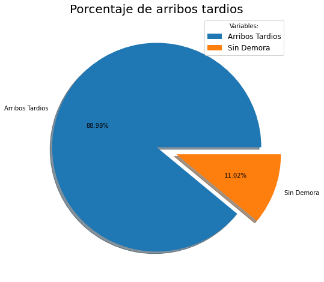

```python
Arrivos_t = df['arribos tardios'].value_counts()
plt.figure(figsize=(8,8))
labels = ["Arribos Tardios", "Sin Demora"]
explode = [0, 0.2]
plt.pie(Arrivos_t, labels = labels, autopct='%.2f%%', explode=explode, shadow=True)

plt.title("Porcentaje de arribos tardios",fontsize=20)
plt.legend(title= "Variables:", fontsize=12)


plt.show()
```

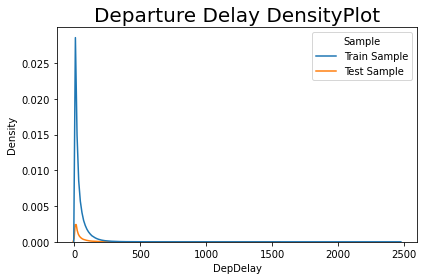

```python
#Plot the density of Departure Delay between our Train and Test Sample:
%matplotlib inline
sns.kdeplot(data=df_concat, x="DepDelay", hue="Sample")
plt.title("Departure Delay DensityPlot",fontsize=20)
plt.tight_layout()
plt.show()
```

```python
#Flights with highest Carrier Delay:

mean_carrierD = df['CarrierDelay'].mean()
most_carrierD = df[df['CarrierDelay'] > mean_carrierD]
most_carrierD.head()
```

|  | Year | Month | DayofMonth | DayOfWeek | DepTime | CRSDepTime | ArrTime | CRSArrTime | UniqueCarrier | FlightNum | ... | Cancelled | CancellationCode | Diverted | CarrierDelay | WeatherDelay | NASDelay | SecurityDelay | LateAircraftDelay | velocidad media | arribos tardios |
| --- | --- | --- | --- | --- | --- | --- | --- | --- | --- | --- | --- | --- | --- | --- | --- | --- | --- | --- | --- | --- | --- |
| 26 | 2008 | 1 | 3 | 4 | 1422.0 | 1255 | 1657.0 | 1610 | WN | 188 | ... | 0 | N | 0 | 40.0 | 0.0 | 0.0 | 0.0 | 7.0 | 7.643357 | Arribo Tarde |
| 49 | 2008 | 1 | 3 | 4 | 2245.0 | 1730 | 2354.0 | 1850 | WN | 186 | ... | 0 | N | 0 | 282.0 | 0.0 | 0.0 | 0.0 | 22.0 | 6.084746 | Arribo Tarde |
| 52 | 2008 | 1 | 3 | 4 | 2025.0 | 1940 | 2135.0 | 2100 | WN | 3154 | ... | 0 | N | 0 | 26.0 | 0.0 | 0.0 | 0.0 | 9.0 | 5.983333 | Arribo Tarde |
| 57 | 2008 | 1 | 3 | 4 | 646.0 | 620 | 725.0 | 655 | WN | 1580 | ... | 0 | N | 0 | 26.0 | 0.0 | 4.0 | 0.0 | 0.0 | 6.285714 | Arribo Tarde |
| 82 | 2008 | 1 | 3 | 4 | 1327.0 | 1230 | 1550.0 | 1500 | WN | 1171 | ... | 0 | N | 0 | 50.0 | 0.0 | 0.0 | 0.0 | 0.0 | 7.492308 | Arribo Tarde |

5 rows × 31 columns

Lets see the longest flights by Airline

```python
mean_airT = df['AirTime'].mean()
longest_flights = df[df['AirTime'] > mean_airT]
longest_flights.head()
```

|  | Year | Month | DayofMonth | DayOfWeek | DepTime | CRSDepTime | ArrTime | CRSArrTime | UniqueCarrier | FlightNum | ... | Cancelled | CancellationCode | Diverted | CarrierDelay | WeatherDelay | NASDelay | SecurityDelay | LateAircraftDelay | velocidad media | arribos tardios |
| --- | --- | --- | --- | --- | --- | --- | --- | --- | --- | --- | --- | --- | --- | --- | --- | --- | --- | --- | --- | --- | --- |
| 0 | 2008 | 1 | 3 | 4 | 2003.0 | 1955 | 2211.0 | 2225 | WN | 335 | ... | 0 | N | 0 | NaN | NaN | NaN | NaN | NaN | 6.982759 | Sin Demora |
| 1 | 2008 | 1 | 3 | 4 | 754.0 | 735 | 1002.0 | 1000 | WN | 3231 | ... | 0 | N | 0 | NaN | NaN | NaN | NaN | NaN | 7.168142 | Arribo Tarde |
| 6 | 2008 | 1 | 3 | 4 | 1937.0 | 1830 | 2037.0 | 1940 | WN | 509 | ... | 0 | N | 0 | 10.0 | 0.0 | 0.0 | 0.0 | 47.0 | 6.917391 | Arribo Tarde |
| 16 | 2008 | 1 | 3 | 4 | 1452.0 | 1425 | 1640.0 | 1625 | WN | 675 | ... | 0 | N | 0 | 3.0 | 0.0 | 0.0 | 0.0 | 12.0 | 6.990610 | Arribo Tarde |
| 17 | 2008 | 1 | 3 | 4 | 754.0 | 745 | 940.0 | 955 | WN | 1144 | ... | 0 | N | 0 | NaN | NaN | NaN | NaN | NaN | 7.263415 | Sin Demora |

5 rows × 31 columns

```python
longest_flights['AirTime'].head()
```

```
0     116.0
1     113.0
6     230.0
16    213.0
17    205.0
Name: AirTime, dtype: float64
```

```python
longest_flights= longest_flights.sort_values(by='AirTime',ascending=False)
```

```python
longest_flights.head()
```

[output not shown]

```python
order = longest_flights.groupby('UniqueCarrier')['AirTime'].mean()
order = order.sort_values(ascending=False)
order.head()
```

```
UniqueCarrier
HA    307.962118
AQ    302.837004
US    204.449819
DL    201.741116
UA    195.720918
Name: AirTime, dtype: float64
```

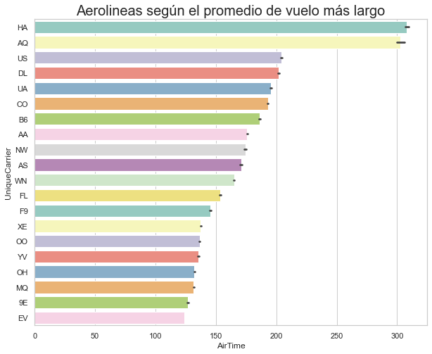

```python
y= longest_flights['UniqueCarrier']
x= longest_flights['AirTime']
plt.figure(figsize =(10, 8))
sns.set(style="whitegrid")
sns.barplot(x=x, y=y, data=longest_flights, order=order.index, palette="Set3")
plt.title('Aerolineas según el promedio de vuelo más largo', size=20)
plt.show()
```

```python
data = df[["UniqueCarrier","ArrDelay","DepDelay"]]
data = data.groupby("UniqueCarrier")[["ArrDelay","DepDelay"]].sum()
data= data.sort_values(by="ArrDelay", ascending=False)
labels = data.index
```

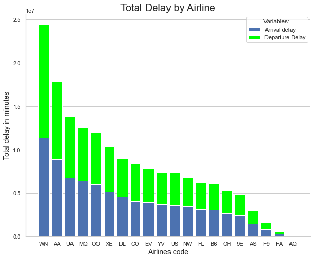

```python
fig, ax = plt.subplots(figsize=(10,8))

ax.bar(data.index, data["ArrDelay"],label="Arrival delay")
ax.bar(data.index, data["DepDelay"], bottom=data["ArrDelay"],label= "Departure Delay",color='lime')
ax.set_title("Total Delay by Airline",fontsize=20)
ax.set_ylabel("Total delay in minutes", fontsize=14)
ax.set_xlabel("Airlines code", fontsize=14)

ax.spines['top'].set_visible(False)
ax.spines['right'].set_visible(False)

ax.yaxis.grid(True)
ax.xaxis.grid(False)

plt.legend(loc="best", title="Variables:")



plt.show()
```